# PS02

Fatima Fairfax

9/4/21

Problem Set 2! Data Visualization

First I will start by loading the relevant packages:

```r
library(dplyr)
```

```r
library(ggplot2)
library(readr)
```

Next I will read in the data, birth data from North Carolina:

```r
nc <- read_csv("https://docs.google.com/spreadsheets/d/e/2PACX-1vTm2WZwNBoQdZhMgot7urbtu8eG7tzAq-60ZJsQ_nupykCAcW0OXebVpHksPWyR4x8xJTVQ8KAulAFS/pub?gid=202410847&single=true&output=csv")
```

Next I’ll take a peek at the data:

```r
glimpse(nc)
```

```
## Rows: 800
## Columns: 13
## $ fage           <dbl> 19, 21, 18, 17, 20, 30, 21, 14, 16, 20, 18, 20, 20, 26,…
## $ mage           <dbl> 15, 15, 15, 15, 16, 16, 16, 16, 16, 17, 17, 17, 17, 17,…
## $ mature         <chr> "younger mom", "younger mom", "younger mom", "younger m…
## $ weeks          <dbl> 37, 41, 37, 35, 37, 45, 38, 40, 24, 40, 37, 40, 39, 38,…
## $ premie         <chr> "full term", "full term", "full term", "premie", "full …
## $ visits         <dbl> 11, 6, 12, 5, 13, 9, 15, 12, 5, 8, 10, 17, 9, 11, 10, 1…
## $ marital        <chr> "married", "married", "married", "married", "married", …
## $ gained         <dbl> 38, 34, 76, 15, 52, 28, 75, 9, 12, 20, 39, 38, 36, 30, …
## $ weight         <dbl> 6.63, 8.00, 8.44, 4.69, 6.94, 7.44, 7.56, 5.81, 1.50, 8…
## $ lowbirthweight <chr> "not low", "not low", "not low", "low", "not low", "not…
## $ gender         <chr> "female", "male", "male", "male", "female", "male", "fe…
## $ habit          <chr> "nonsmoker", "nonsmoker", "nonsmoker", "nonsmoker", "no…
## $ whitemom       <chr> "white", "white", "not white", "not white", "white", "w…
```

There are 13 variables (columns) and 800 observations (rows).

**Exercise 1** The *habit* variable is a character variable and the *visits* variable is a decimal.

Next I’ll make a scatterplot looking at the weeks (length of pregnancy) against weight (birth weight of the baby):

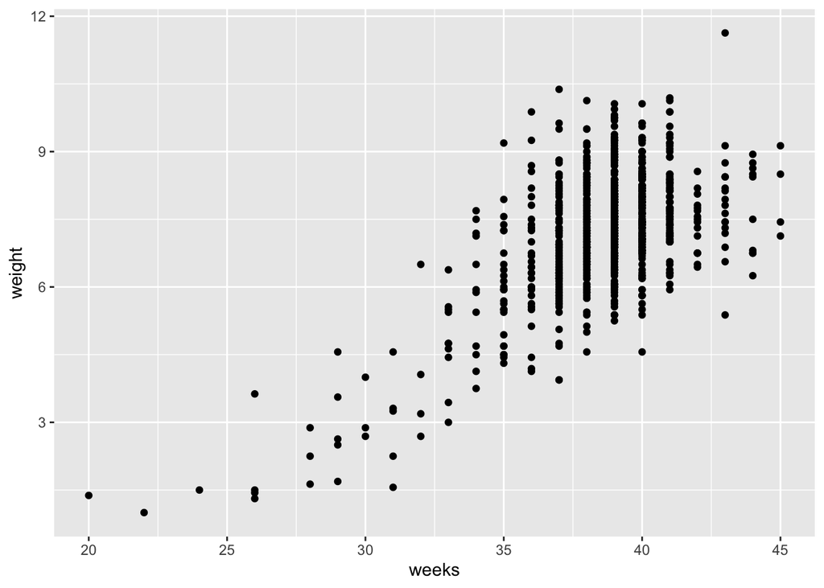

```r
ggplot(data = nc, mapping = aes(x = weeks, y=weight)) +
  geom_point()
```

Now I’m going to do the same thing but will add some labels and a title:

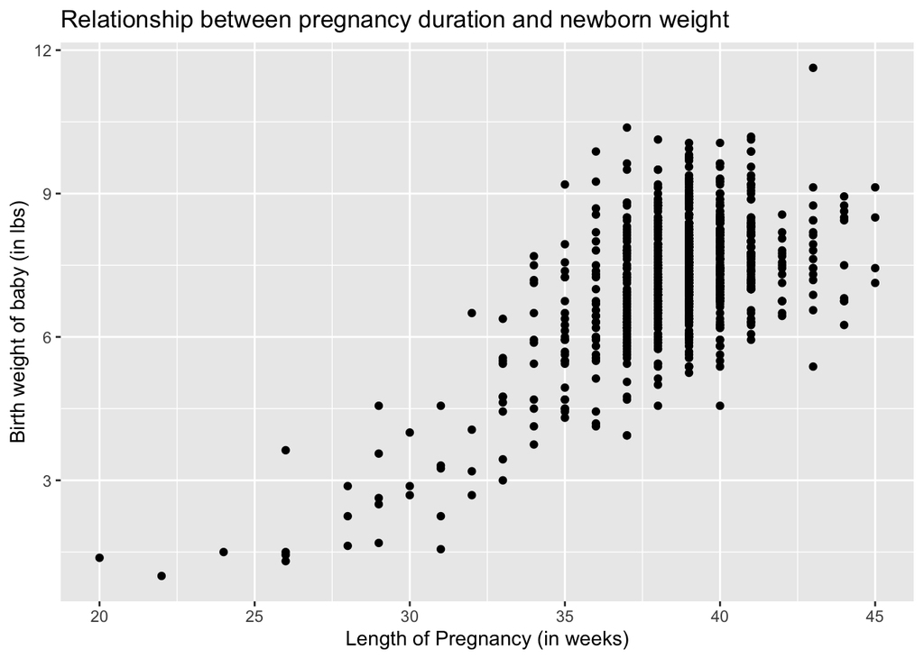

```r
ggplot(data = nc, mapping = aes(x=weeks, y=weight)) +
  geom_point() +
  labs(x="Length of Pregnancy (in weeks)", y = "Birth weight of baby (in lbs)",
       title = "Relationship between pregnancy duration and newborn weight")
```

**Exercise 2**

There is a positive relationship between these variables. As the duration of preganancy increases, the birth weight increases.

**Exercise 3** Making a new graph with weeks on the x and ‘gained’ on the y with labels and a title:

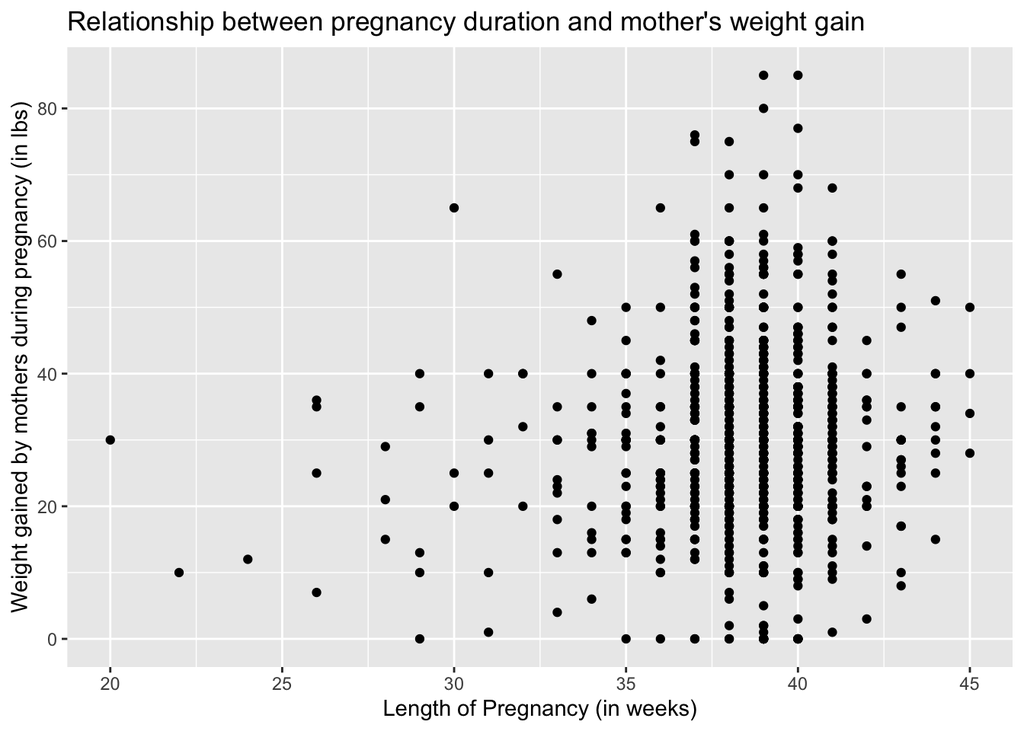

```r
ggplot(data = nc, mapping = aes(x=weeks, y = gained)) +
  geom_point() +
  labs(x = "Length of Pregnancy (in weeks)", y = "Weight gained by mothers during pregnancy (in lbs)",
       title = "Relationship between pregnancy duration and mother's weight gain")
```

**Exercise 5**

Here is a new scatterplot that shows mothers age on the x and birth weight of the babies on the y and color coded based on the gender of the baby.

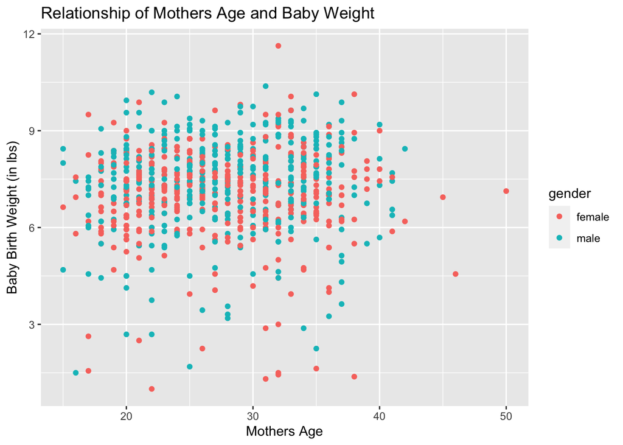

```r
ggplot(data = nc, mapping = aes(x = mage, y = weight, color = gender)) +
  geom_point() +
  labs(x = "Mothers Age", y = "Baby Birth Weight (in lbs)",
       title = "Relationship of Mothers Age and Baby Weight")
```

There doesn’t seem to be a strong relationship between mothers age and baby birth weight from this data. The baby birth rate does not seem to fluxuate based on the mother’s age.

Now I’m looking at histograms. Here is the distribution of pregnancy duration:

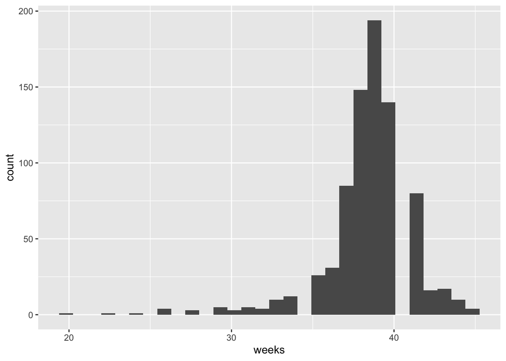

```r
ggplot(data = nc, aes(x=weeks)) +
  geom_histogram()
```

I’m going to change the bandwidth and add colors:

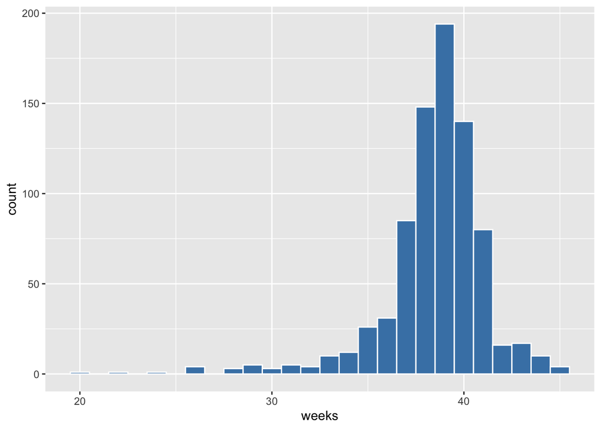

```r
ggplot(data = nc, aes(x = weeks)) +
  geom_histogram(binwidth = 1, color = "white", fill = "steelblue")
```

**Exercise 6**

A. The y label, count, provides the number of babies born in a certain week range (the bins).

**Exercise 7** Now I’ll make a histogram of birth weight of newborns in lbs and include a title and axis labels:

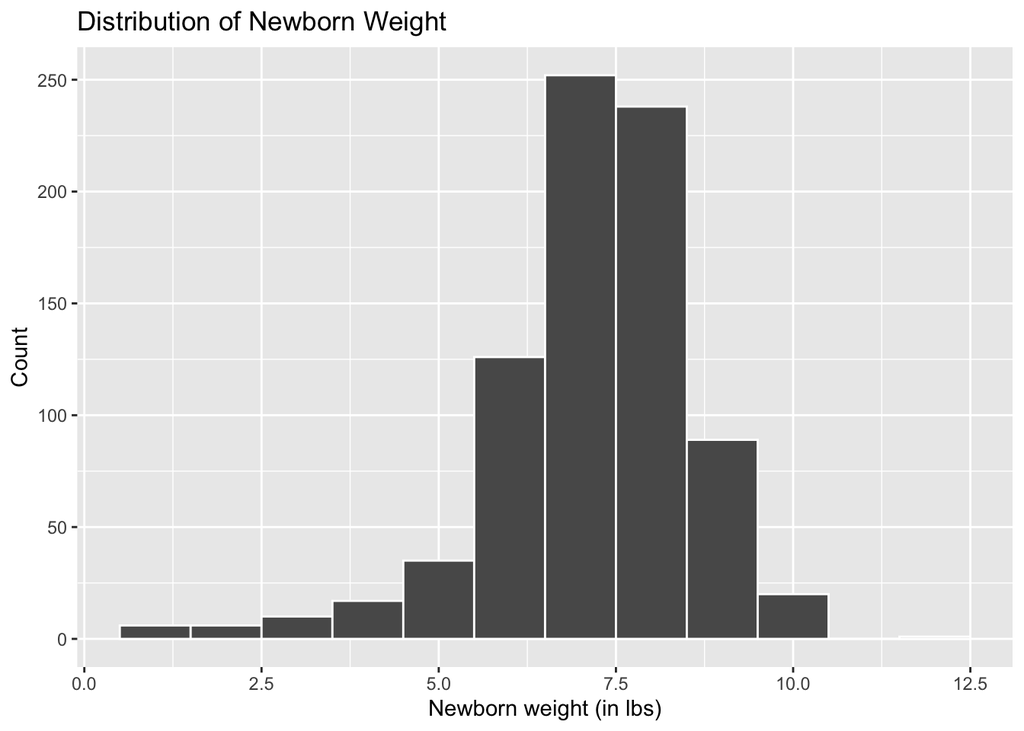

```r
ggplot(data = nc, mapping = aes(x = weight)) +
  geom_histogram(binwidth = 1, color = "white") +
  labs(x = "Newborn weight (in lbs)", y = "Count",
       title = "Distribution of Newborn Weight")
```

Faceting allows us to look at multiples of the same plot over different categorical variables. Now I’ll plot histrograms of weeks of pregnancy for mature and younger moms.

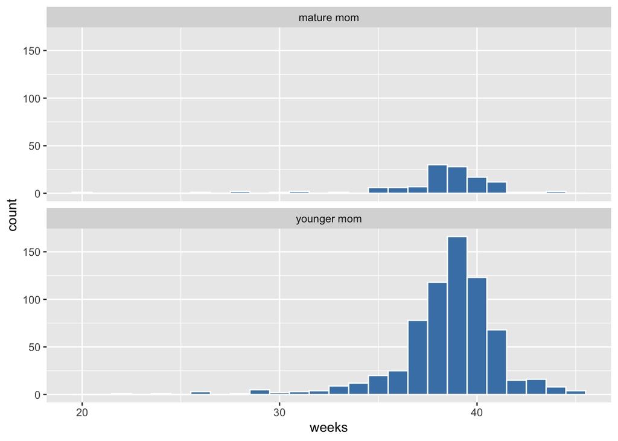

```r
ggplot(data = nc, mapping = aes(x = weeks)) +
  geom_histogram(binwidth = 1, color = "white", fill = "steelblue") +
  facet_wrap(~ mature, ncol = 1)
```

**Exercise 8**

Making a histogram of newborn birth weight split by gender of the child with a binwidth of 0.5.

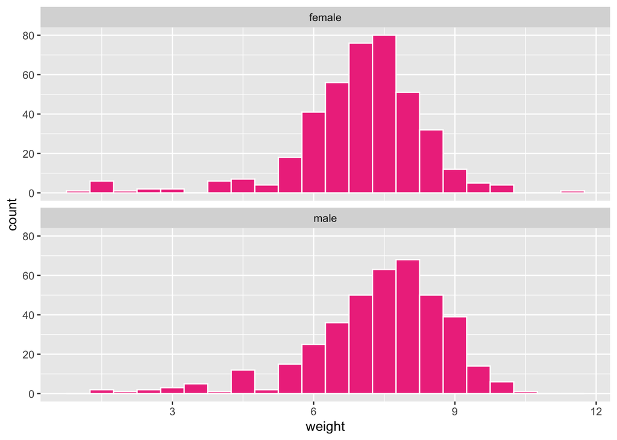

```r
ggplot(nc, aes(x=weight)) +
  geom_histogram(binwidth = 0.5, color = "white", fill = "violetred2") +
  facet_wrap(~gender, ncol = 1)
```

It looks like males have a slightly higher average birth weight.

Now looking at boxplots! Setting a boxplot to look at weight gained for mothers and gender:

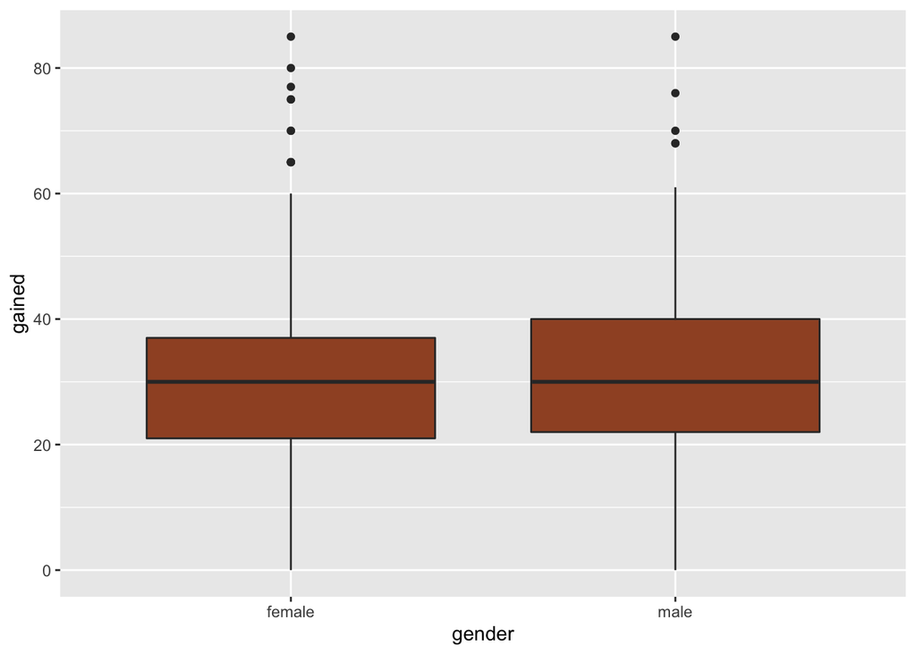

```r
ggplot(nc, aes(x = gender, y = gained)) +
  geom_boxplot(fill = "sienna")
```

**Exercise 9**

Making a boxplot of weight gained by moms split by maturying of the mother with labels and a title:

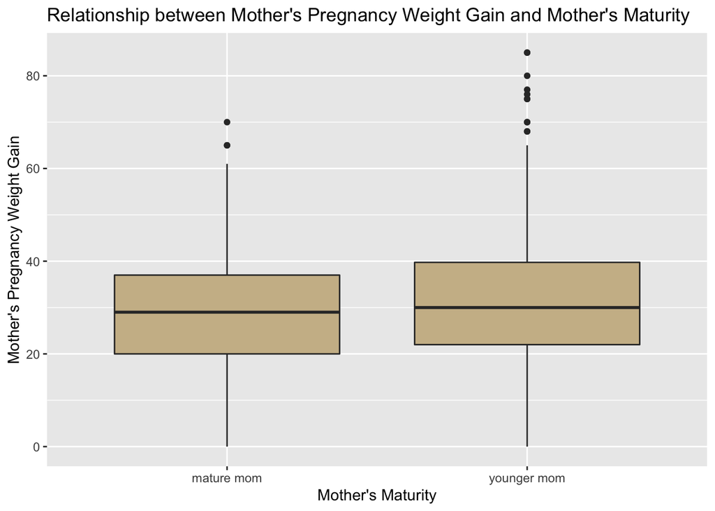

```r
ggplot(nc, aes(x = mature, y = gained)) +
  geom_boxplot(fill = "wheat3") +
  labs(x = "Mother's Maturity", y = "Mother's Pregnancy Weight Gain",
       title = "Relationship between Mother's Pregnancy Weight Gain and Mother's Maturity")
```

The median weight gian is larger for younger mom’s.

**Exercise 10**

Now a boxplot of pregnancy duration by the habit of smoking.

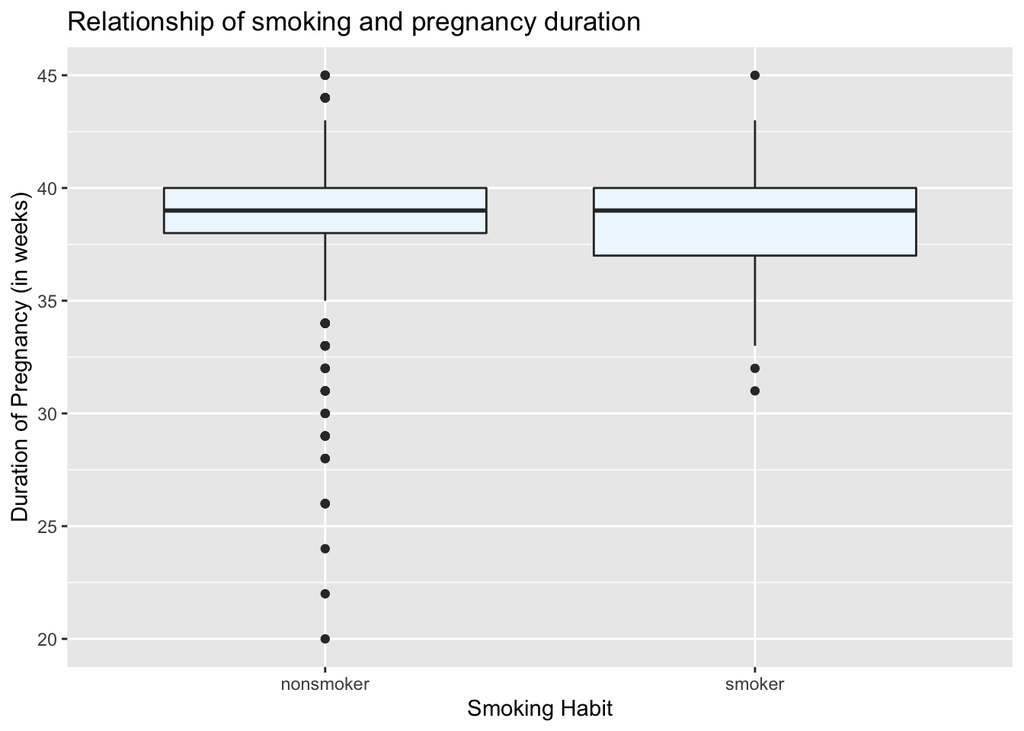

```r
ggplot(nc, aes(x = habit, y = weeks)) +
  geom_boxplot(fill = "aliceblue") +
  labs(x = "Smoking Habit", y = "Duration of Pregnancy (in weeks)",
       title = "Relationship of smoking and pregnancy duration")
```

**Exercise 11**

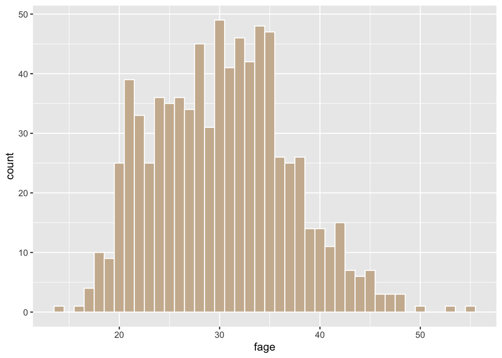

```r
ggplot(nc, aes(x = fage)) +
  geom_histogram(binwidth = 1, color = "white", fill = "bisque3")
```

**Exercise 12**

Is the median birth weight of babies greater for white or non-white mothers? In this data set, the median birth weight is higher for white moms than non-white moms.

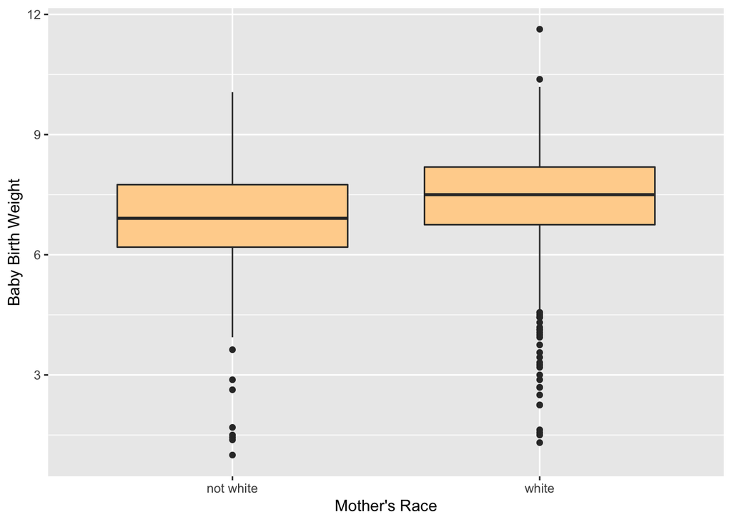

```r
ggplot(nc, aes(x = whitemom, y = weight)) +
  geom_boxplot(fill = "burlywood1") +
  labs(x = "Mother's Race", y = "Baby Birth Weight")
```

**Exercise 13**

As the mother’s age increase, does the duration of pregnancy decrease? In this data, that does not appear to be the case.

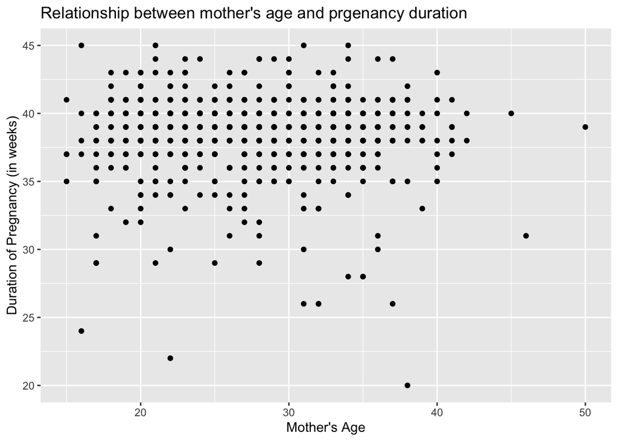

```r
ggplot(nc, aes(x = mage, y = weeks)) +
  geom_point() +
  labs(x = "Mother's Age", y = "Duration of Pregnancy (in weeks)",
       title = "Relationship between mother's age and prgenancy duration")
```

**testing new text to see if it allows a new save**